# Insert chapter 2 title here

# 3. Fitting regression line

```r
# Regression model with three explantory variables
my_model_1 <- lm(points ~ attitude + stra + deep, data = learning2014)
summary(my_model_1)
```

```
##
## Call:
## lm(formula = points ~ attitude + stra + deep, data = learning2014)
##
## Residuals:
##      Min       1Q   Median       3Q      Max
## -17.5239  -3.4276   0.5474   3.8220  11.5112
##
## Coefficients:
##             Estimate Std. Error t value Pr(>|t|)
## (Intercept)  11.3915     3.4077   3.343  0.00103 **
## attitude      3.5254     0.5683   6.203 4.44e-09 ***
## stra          0.9621     0.5367   1.793  0.07489 .
## deep         -0.7492     0.7507  -0.998  0.31974
## ---
## Signif. codes:  0 '***' 0.001 '**' 0.01 '*' 0.05 '.' 0.1 ' ' 1
##
## Residual standard error: 5.289 on 162 degrees of freedom
## Multiple R-squared:  0.2097, Adjusted R-squared:  0.195
## F-statistic: 14.33 on 3 and 162 DF,  p-value: 2.521e-08
```

```r
# Excluding "deep" variable due to its insignificant relationship with  "points"
my_model_2 <- lm(points ~ attitude + stra, data = learning2014)
summary(my_model_2)
```

```
##
## Call:
## lm(formula = points ~ attitude + stra, data = learning2014)
##
## Residuals:
##      Min       1Q   Median       3Q      Max
## -17.6436  -3.3113   0.5575   3.7928  10.9295
##
## Coefficients:
##             Estimate Std. Error t value Pr(>|t|)
## (Intercept)   8.9729     2.3959   3.745  0.00025 ***
## attitude      3.4658     0.5652   6.132 6.31e-09 ***
## stra          0.9137     0.5345   1.709  0.08927 .
## ---
## Signif. codes:  0 '***' 0.001 '**' 0.01 '*' 0.05 '.' 0.1 ' ' 1
##
## Residual standard error: 5.289 on 163 degrees of freedom
## Multiple R-squared:  0.2048, Adjusted R-squared:  0.1951
## F-statistic: 20.99 on 2 and 163 DF,  p-value: 7.734e-09
```

```r
# Excluding "stra" variable as well
my_model_3 <- lm(points ~ attitude, data = learning2014)
summary(my_model_3)
```

```
##
## Call:
## lm(formula = points ~ attitude, data = learning2014)
##
## Residuals:
##      Min       1Q   Median       3Q      Max
## -16.9763  -3.2119   0.4339   4.1534  10.6645
##
## Coefficients:
##             Estimate Std. Error t value Pr(>|t|)
## (Intercept)  11.6372     1.8303   6.358 1.95e-09 ***
## attitude      3.5255     0.5674   6.214 4.12e-09 ***
## ---
## Signif. codes:  0 '***' 0.001 '**' 0.01 '*' 0.05 '.' 0.1 ' ' 1
##
## Residual standard error: 5.32 on 164 degrees of freedom
## Multiple R-squared:  0.1906, Adjusted R-squared:  0.1856
## F-statistic: 38.61 on 1 and 164 DF,  p-value: 4.119e-09
```

In the first model, we have used three explanatory variables of “attitude”, “stra”, and “deep”. According to the summary, there is no significant relationship between “deep” and “points”. Thus, we removed “deep” variable from the model, and fit the model again with “attitude” and “stra” as the explanatory variables; still, it seems “stra” has not statistically significant relationship with our target variable, “points”. So, we fit the model once again with only “attitude” as its explanatory variable. The summary shows a significant linear relationship between “attitude” and “points” which means those who have positive attitude toward statistics, get better points in this course.

# 4. Parameter interpretaion

Using the summary of fitted model, multiple R-squared in all three level, is low which indicates a weak relationship between our explanatory variables and points. However only one of these weak estimating relationship (between attitude and points) is significant.

# 5. diagnostic plots

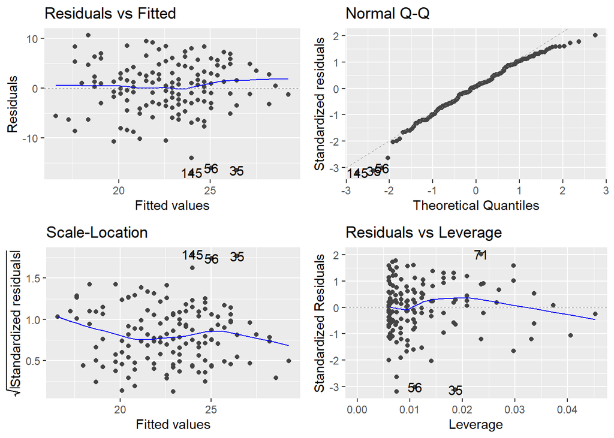

```r
library(ggfortify)
autoplot(my_model_3)
```

The assumptions of linear regression are: - The relationship between the predictor (x) and the outcome (y) is assumed to be linear. - The residual errors are assumed to be normally distributed. - The residuals are assumed to have a constant variance (homoscedasticity) - residuals error terms are independent.